# Palmer Penguins Mini Project

Anmol Sandhu

## Introduction

This project examines morphological variation in penguins using the Palmer Penguins dataset. The primary objective is to assess whether the relationship between flipper length and body mass differs across species.

Reproducible research practices are essential for transparent and reliable scientific findings (Bhattacharya et al., 2025).

## Research Question

Does the relationship between flipper length and body mass differ across penguin species?

## Hypothesis

The relationship between flipper length and body mass differs among Adelie, Chinstrap, and Gentoo penguins. Specifically, species with longer flippers are expected to have greater body mass, but the strength of this relationship will vary among species.

## Methods

### Data Source

Data were obtained from the `palmerpenguins` R package and exported as a raw dataset.

### Data Processing

The processed dataset was created by:

- Selecting species, flipper_length_mm, and body_mass_g
- Removing observations with missing values

The final processed dataset contains 342 observations and 3 variables.

### Planned Statistical Analysis

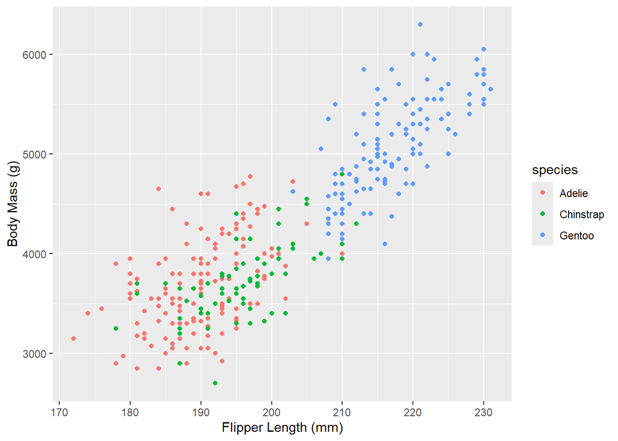

```r
library(ggplot2)

penguins <- read.csv("../data/data_processed/penguins_processed.csv")

ggplot(penguins, aes(x = flipper_length_mm, y = body_mass_g, color = species)) +
  geom_point() +
  labs(
    x = "Flipper Length (mm)",
    y = "Body Mass (g)"
  )
```

Figure 1. Relationship between flipper length and body mass across penguin species.

To evaluate whether the relationship between flipper length and body mass differs among species, a linear regression model including an interaction between flipper length and species was fitted.

```r
library(knitr)
library(broom)

model <- lm(body_mass_g ~ flipper_length_mm * species, data = penguins)

tidy(model) |>
  kable(caption = " Linear regression model examining the interaction between flipper length and species on penguin body mass.")
```

Linear regression model examining the interaction between flipper length and species on penguin body mass.

| term | estimate | std.error | statistic | p.value |
| --- | --- | --- | --- | --- |
| (Intercept) | -2535.836802 | 879.467667 | -2.8833770 | 0.0041879 |
| flipper_length_mm | 32.831690 | 4.627184 | 7.0953936 | 0.0000000 |
| speciesChinstrap | -501.358972 | 1523.459013 | -0.3290925 | 0.7422908 |
| speciesGentoo | -4251.443811 | 1427.332228 | -2.9785944 | 0.0031064 |
| flipper_length_mm:speciesChinstrap | 1.741704 | 7.855734 | 0.2217112 | 0.8246734 |
| flipper_length_mm:speciesGentoo | 21.790812 | 6.941167 | 3.1393586 | 0.0018433 |

The interaction between flipper length and species was significant for Gentoo penguins (p = 0.00184), indicating that the relationship between flipper length and body mass differs among species.

## References

Bhattacharya, S., Prusty, S., Pande, S. P., Gulhane, M., Lavate, S. H., Rakesh, N., & Veerasamy, S. (2025). Integration of multimodal imaging data with machine learning for improved diagnosis and prognosis in neuroimaging. *Frontiers in Human Neuroscience*, *19*. https://doi.org/10.3389/fnhum.2025.1552178